# DataFest 2021: Team K-Bandits

Tiffany Feng, Eustina Kim, Diana Pham, Kienna Qin

UCLA

# Introduction and Objective

Our team **explored which characteristics of each occupation (students, health professionals, and veterans) determined the use of benzodiazepines (BZDs)**, a type of drug that produces sedation and lowers anxiety levels, in the sample of participants in the United States during 2018.

## What contributes the most to the use of BZDs?

### Variable Category Importance

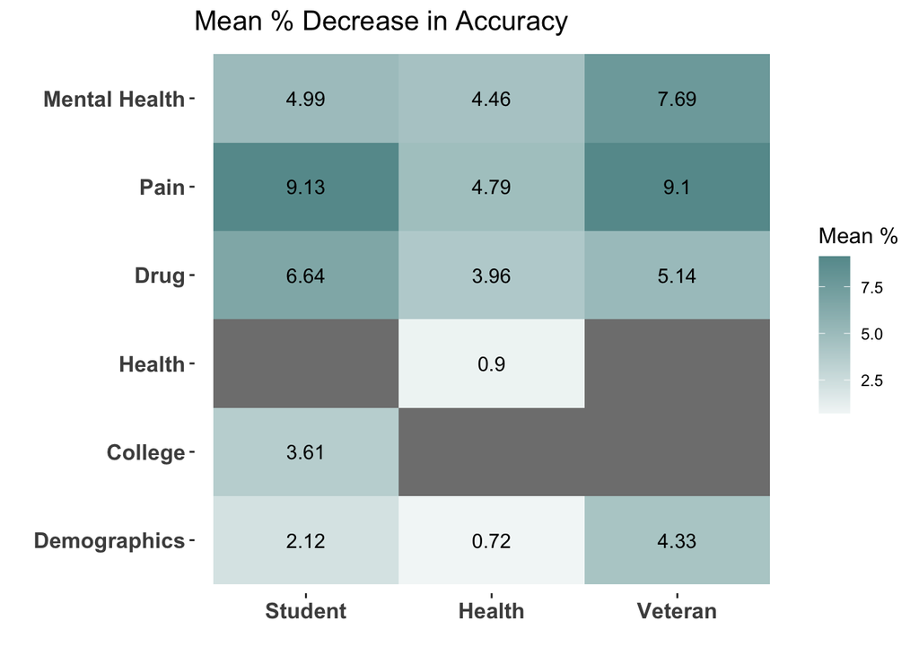

### Variable Importance

Which variables contribute the most to accuracy? The plots below show the 30 most important variables.

#### Students

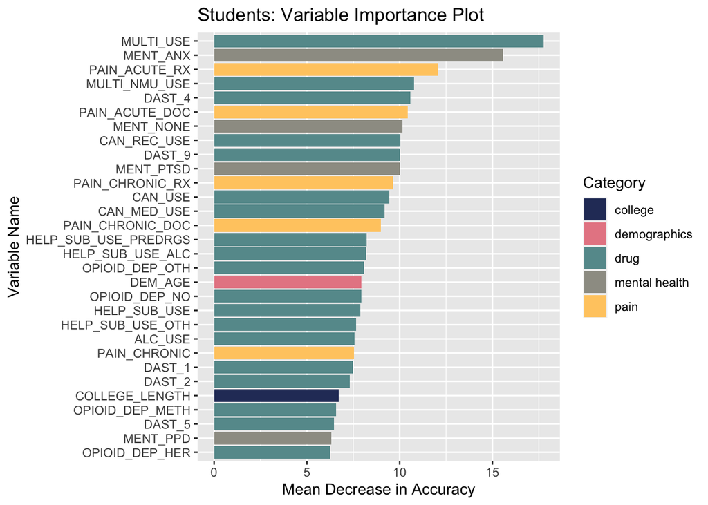

#### Health Professionals

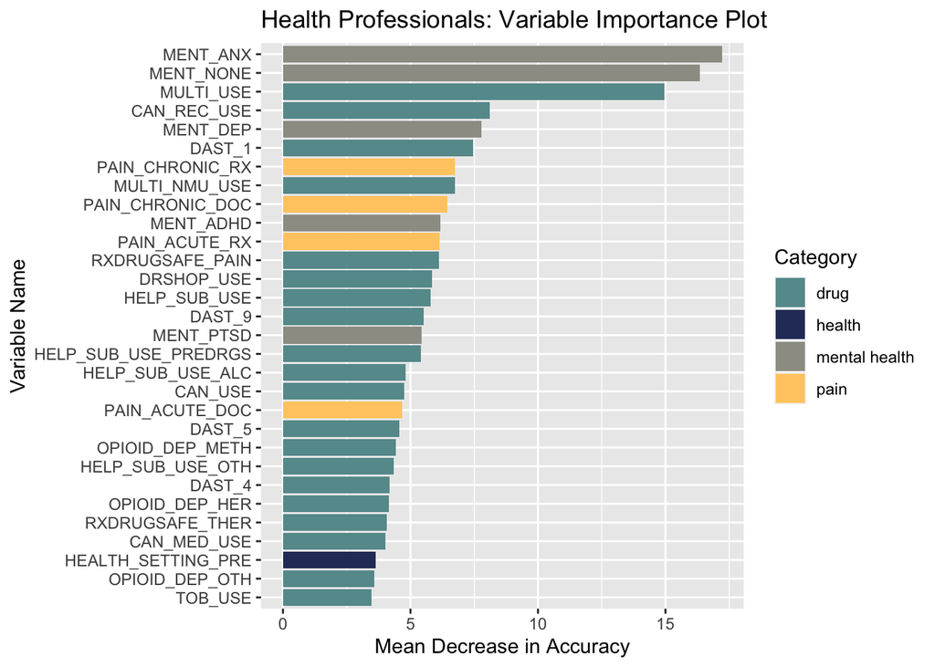

#### Veterans

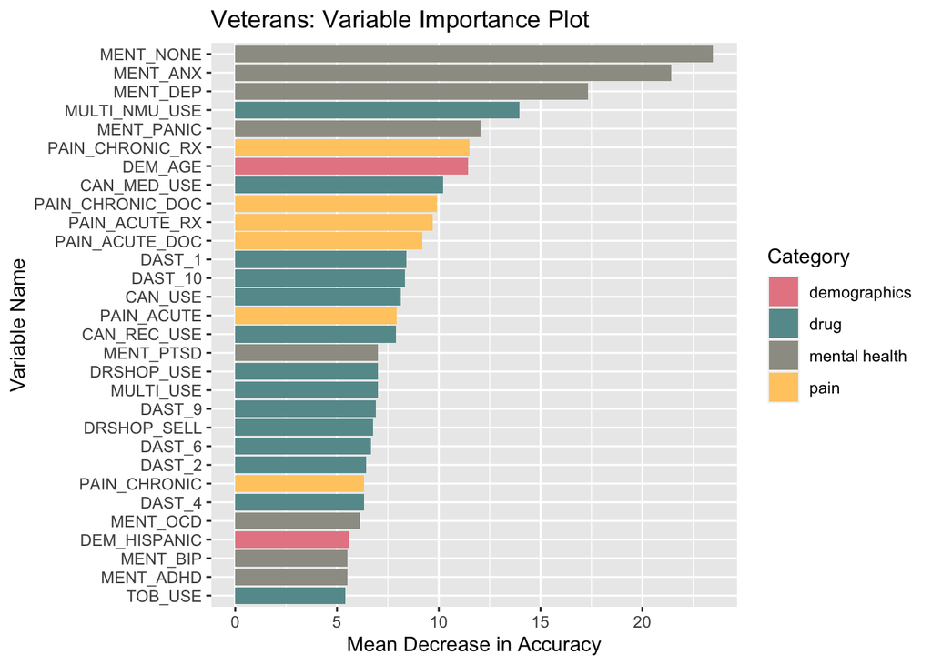

## A Closer Look

### Multi-Use Drugs

#### Students

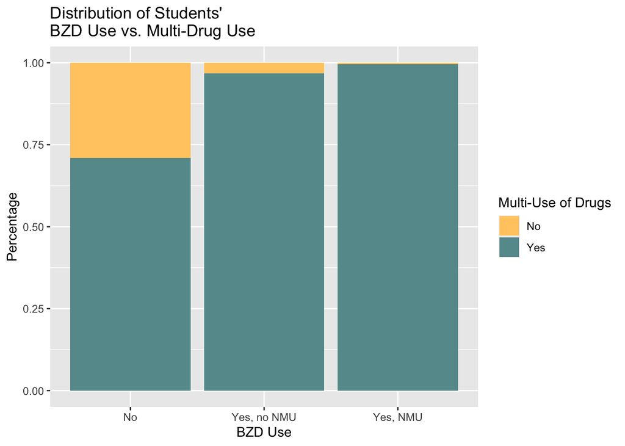

#### Health Professionals

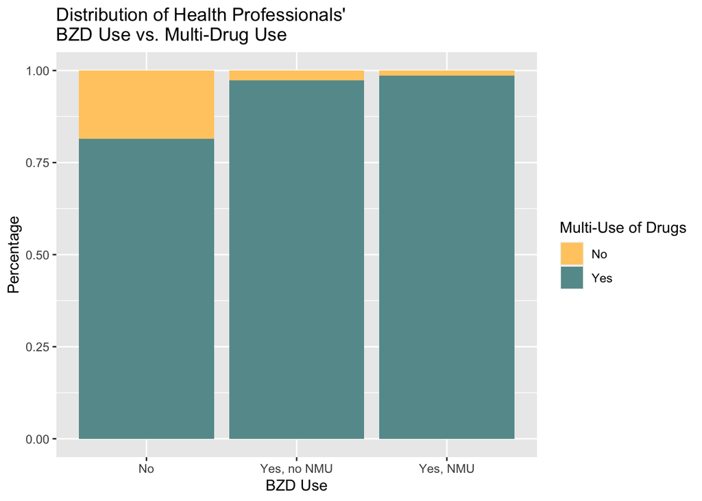

#### Veterans

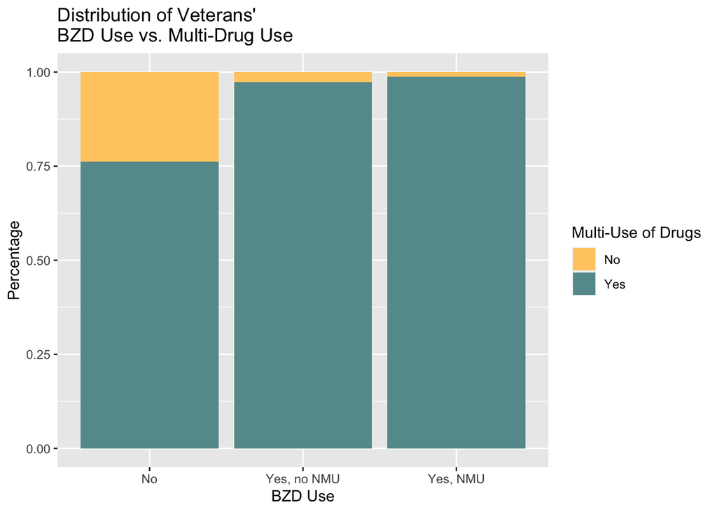

### Multi-NMU Drugs

NMU: Non-medical use

#### Students

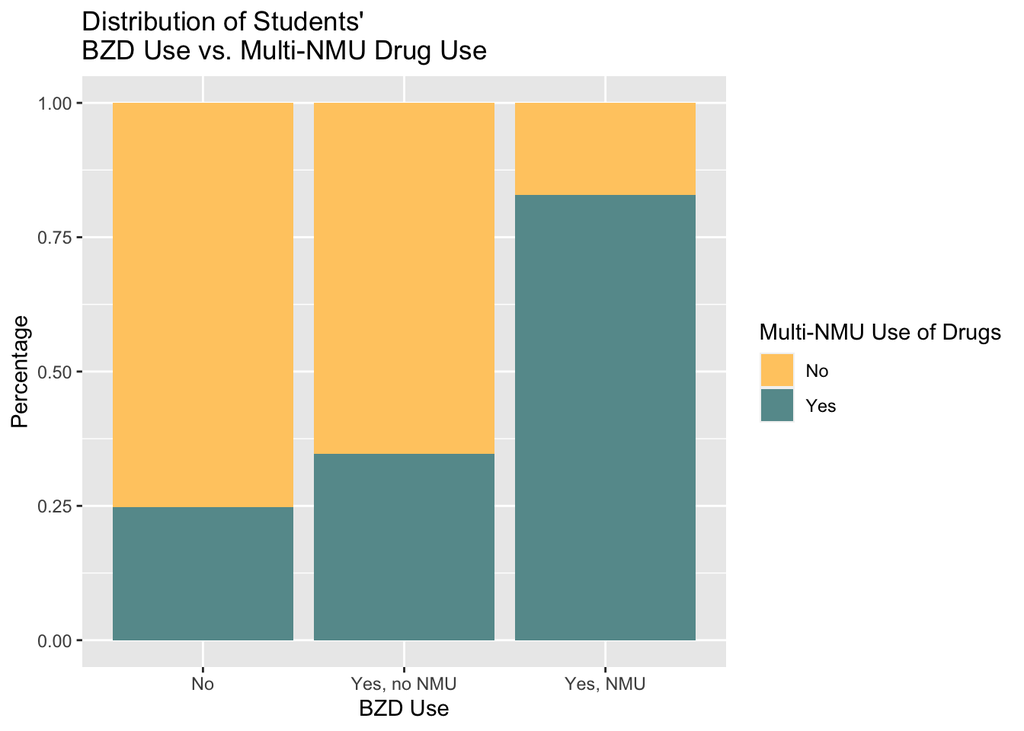

#### Health Professionals

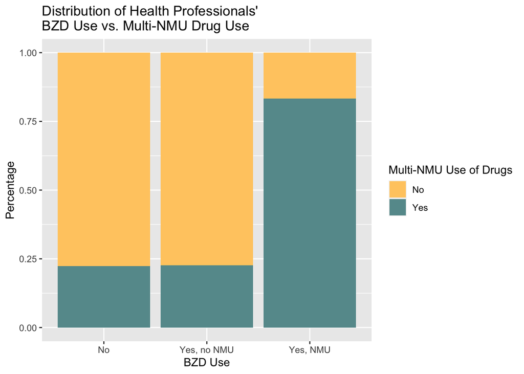

#### Veterans

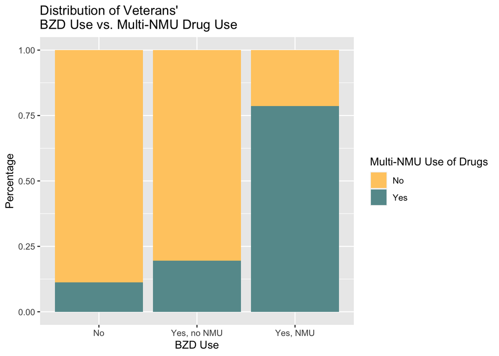

### Mental Health History

#### Students

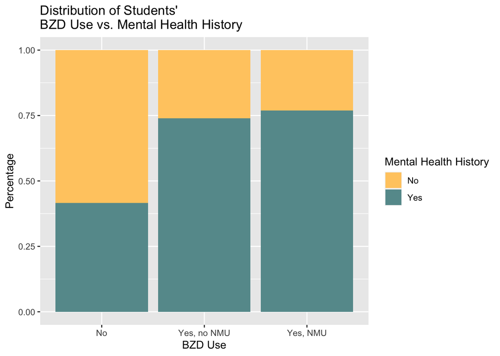

#### Health Professionals

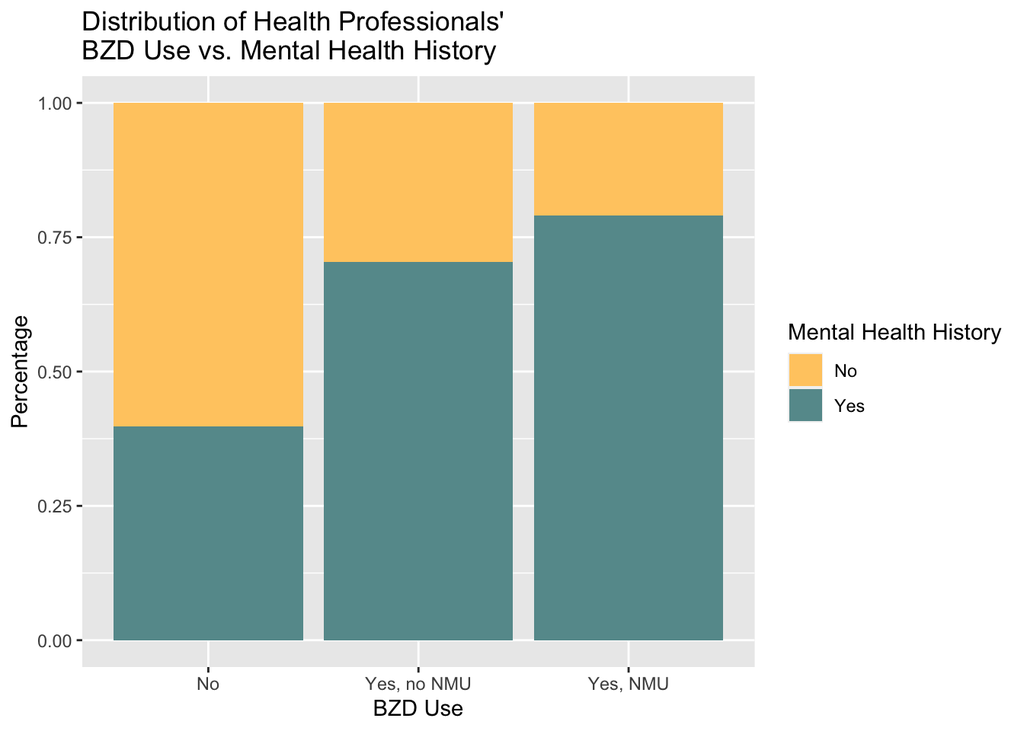

#### Veterans

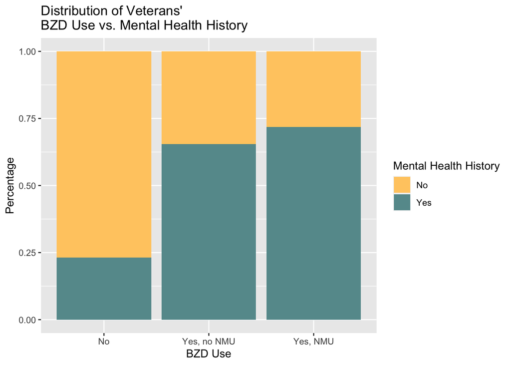

### Chronic Pain

#### Students

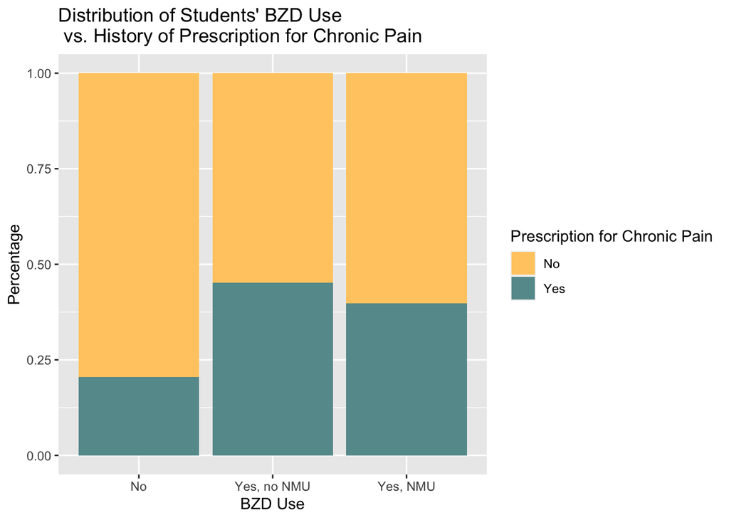

#### Health Professionals

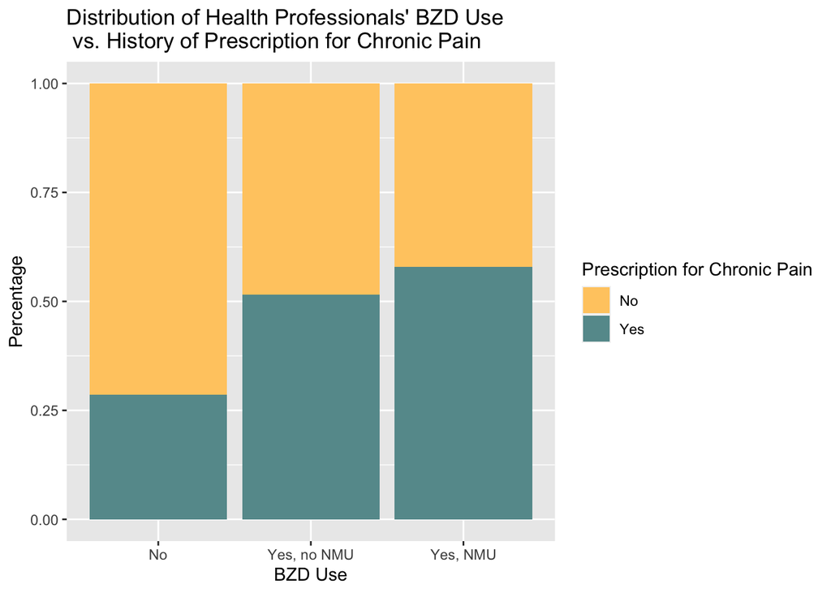

#### Veterans

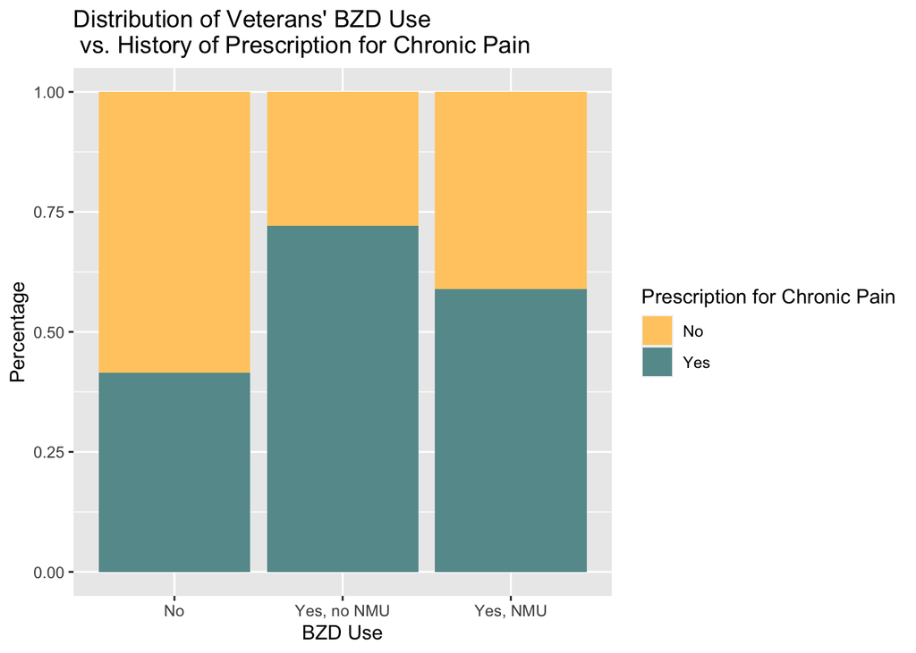

### Demographics

#### Students

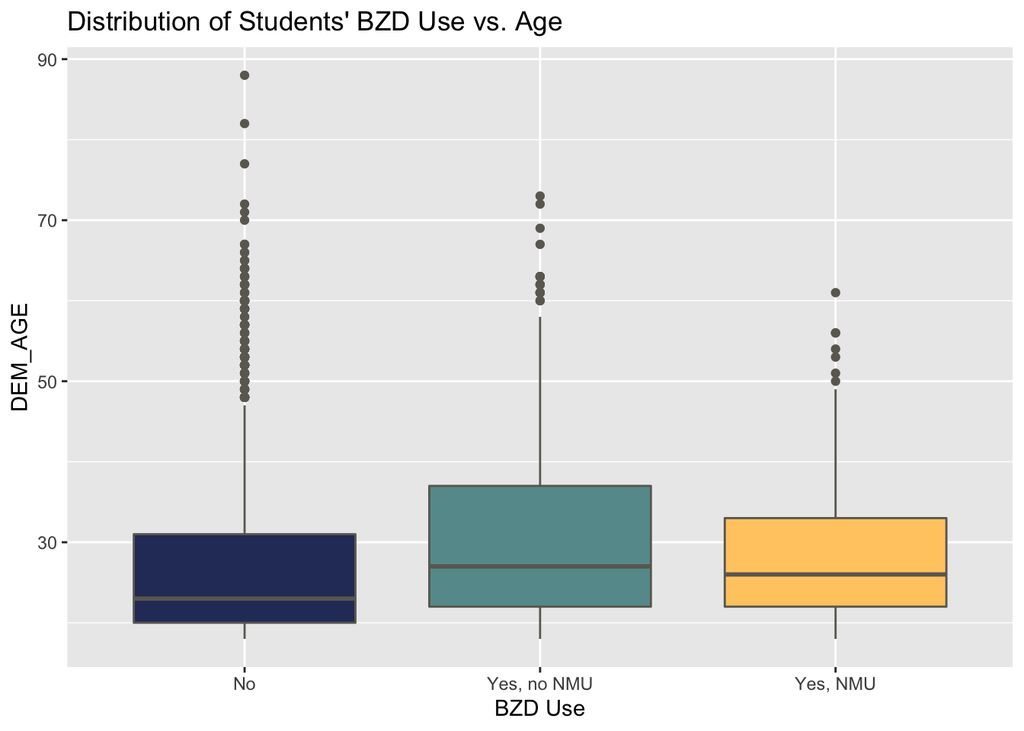

#### Health Professionals

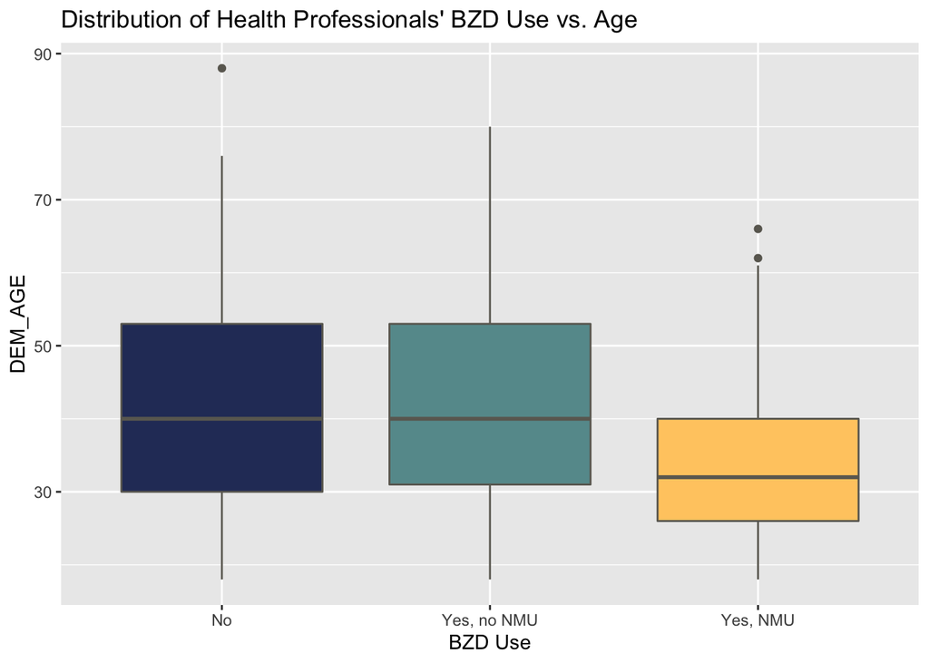

#### Veterans

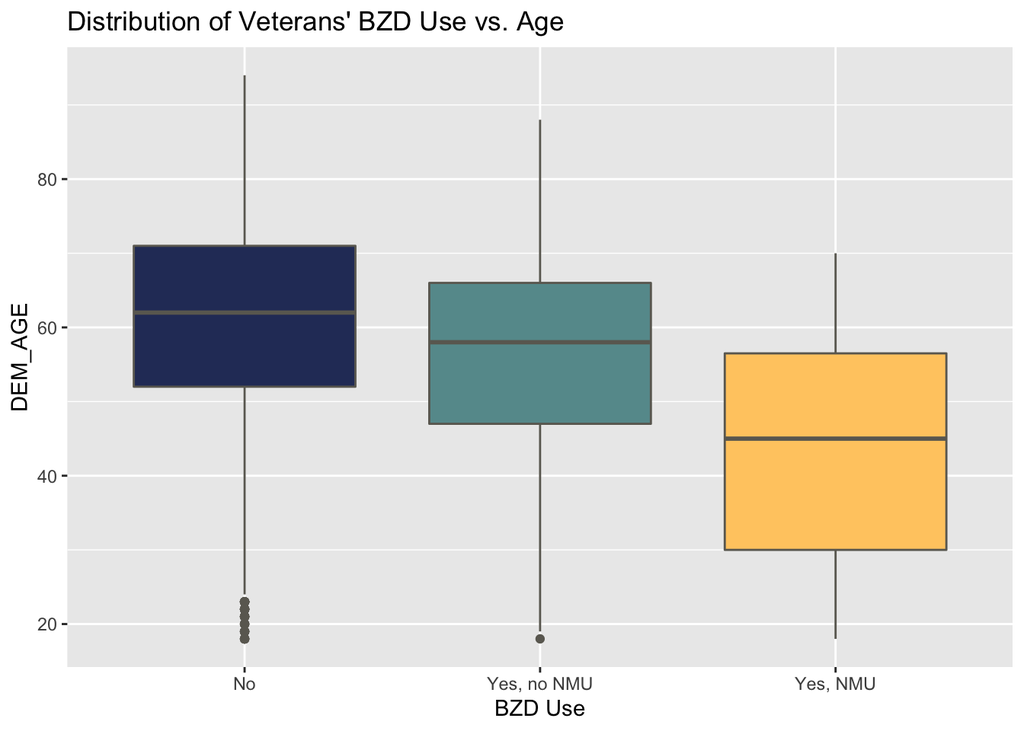

# Limitations & Concluding Thoughts

Having a **history of drug use, mental illness, and prescriptions for opioids for treating pain** are important in predicting the use of BZD for all three occupations.

Our data was not a representative sample and **cannot be generalized to the larger population**.